# Practicle Machine Learning - Course Project

Revital

Friday, June 12, 2015

Using devices such as Jawbone Up, Nike FuelBand, and Fitbit it is now possible to collect a large amount of data about personal activity relatively inexpensively. These type of devices are part of the quantified self movement ? a group of enthusiasts who take measurements about themselves regularly to improve their health, to find patterns in their behavior, or because they are tech geeks. One thing that people regularly do is quantify how much of a particular activity they do, but they rarely quantify how well they do it.

In this project, my goal was to use data from accelerometers on the belt, forearm, arm, and dumbell of 6 participants. The participants were asked to perform barbell lifts correctly and incorrectly in 5 different ways. The data was used to create a prediction model that will predict the way they preformed the barbell lifts. More information on the data is available from the website here http://groupware.les.inf.puc-rio.br/har

## Reading and Cleaning the data

```r
        library(caret)
        trn<- read.csv("pml-training.csv")
        tst<- read.csv("pml-testing.csv")
        dim(trn)
```

```
## [1] 19622   160
```

```r
        dim(tst)
```

```
## [1]  20 160
```

The training dataset contains 19622 observation with 160 variables and the testing data consist of 20 observations, with the same variables’ number.

After reading the data, it is important to clean the irrelevant variables. Reviewing the variables names -

```r
        names(trn)
```

```
##   [1] "X"                        "user_name"
##   [3] "raw_timestamp_part_1"     "raw_timestamp_part_2"
##   [5] "cvtd_timestamp"           "new_window"
##   [7] "num_window"               "roll_belt"
##   [9] "pitch_belt"               "yaw_belt"
##  [11] "total_accel_belt"         "kurtosis_roll_belt"
##  [13] "kurtosis_picth_belt"      "kurtosis_yaw_belt"
##  [15] "skewness_roll_belt"       "skewness_roll_belt.1"
##  [17] "skewness_yaw_belt"        "max_roll_belt"
##  [19] "max_picth_belt"           "max_yaw_belt"
##  [21] "min_roll_belt"            "min_pitch_belt"
##  [23] "min_yaw_belt"             "amplitude_roll_belt"
##  [25] "amplitude_pitch_belt"     "amplitude_yaw_belt"
##  [27] "var_total_accel_belt"     "avg_roll_belt"
##  [29] "stddev_roll_belt"         "var_roll_belt"
```

[output cut: 65 more lines]

1. Manually reviewing the data reveals that the first 7 variables are id variables of the participants and time stamps. Those variables will be removed.
2. From the remaining variables, I have removed both -
- Variables that are near zero (predictors that have one unique value (i.e. are zero variance predictors) or predictors that have very few unique values relative to the number of samples and the ratio of the frequency of the most common value to the frequency of the second most common value is large.)
- Variables that are mostly NA (NA frequency > 95%)

```r
        # removing id variables
        training1<-trn[,-c(1:7)]

        #removing near zero variables
        training1<-training1[,-nearZeroVar(training1)]
        nas<- function(x) {
                sum(is.na(x))/nrow(training1)<0.95
        }
        toKeep <-sapply(training1, nas)
        ftrn<-training1[,toKeep]
        dim(ftrn)
```

```
## [1] 19622    53
```

The new training dataset contains now only 53 variables, and it is ready for evaluation.

## Spliting the training data to train and validation sets

```r
        set.seed(12323)
        inTrain <- createDataPartition(y=ftrn$classe,
                                       p=0.7, list=FALSE)

        ftrn_t <- ftrn[inTrain,]
        ftrn_v <- ftrn[-inTrain,]
```

## Model testing

The most commonly used models are boosting and random forest, both will be tested here.

For both methods I used *cross validation* with K-fold of *5*, to evoid over fitting.

### Testing model 1 - gradient boosted model with cross validation 5 fold

```r
Fit_gbm <- train(classe ~ ., data = ftrn_t,
                 method = "gbm",
                 trControl = trainControl(method = "cv", 5),
                 verbose = FALSE)
Fit_gbm
```

```
## Stochastic Gradient Boosting
##
## 13737 samples
##    52 predictor
##     5 classes: 'A', 'B', 'C', 'D', 'E'
##
## No pre-processing
## Resampling: Cross-Validated (5 fold)
##
## Summary of sample sizes: 10989, 10990, 10989, 10991, 10989
##
## Resampling results across tuning parameters:
##
##   interaction.depth  n.trees  Accuracy   Kappa      Accuracy SD
##   1                   50      0.7514014  0.6847171  0.005955449
##   1                  100      0.8202659  0.7724659  0.005242062
##   1                  150      0.8490935  0.8090190  0.006067604
##   2                   50      0.8498938  0.8097528  0.004038156
##   2                  100      0.9040546  0.8785662  0.004539633
##   2                  150      0.9286598  0.9097342  0.002843270
##   3                   50      0.8927709  0.8642278  0.004287819
##   3                  100      0.9397255  0.9237334  0.003631110
##   3                  150      0.9590162  0.9481481  0.002795071
##   Kappa SD
##   0.007782149
##   0.006602629
##   0.007619538
##   0.005256266
##   0.005754590
##   0.003590945
##   0.005390512
##   0.004585460
##   0.003536744
##
## Tuning parameter 'shrinkage' was held constant at a value of 0.1
##
## Tuning parameter 'n.minobsinnode' was held constant at a value of 10
## Accuracy was used to select the optimal model using  the largest value.
## The final values used for the model were n.trees = 150,
##  interaction.depth = 3, shrinkage = 0.1 and n.minobsinnode = 10.
```

As can be seen in the model results, and in the below figure, the most accurate gbm model was generated using n.trees=150 and interaction.depth=3, and yield **0.959** accuracy.

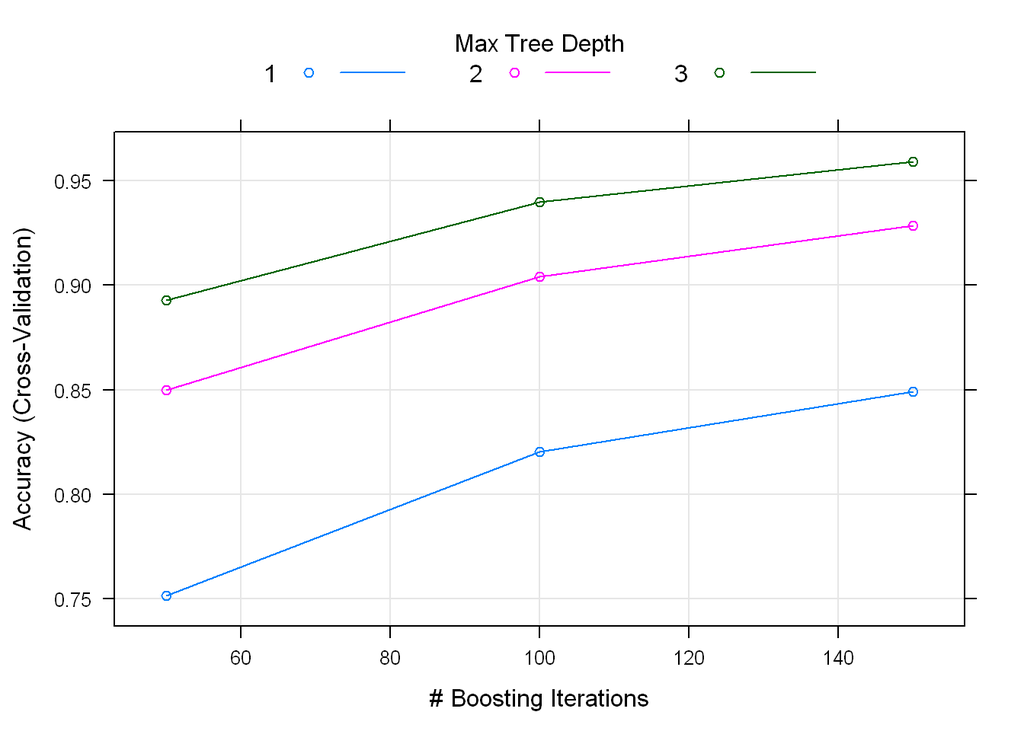

```r
        plot(Fit_gbm)
```

### Testing model 2 - random forest with cross validation 5 fold

```r
        Fit_rf <- train(classe ~ ., data = ftrn_t,
                 method = "rf",
                 trControl = trainControl(method = "cv", 5)
                 )
        Fit_rf
```

```
## Random Forest
##
## 13737 samples
##    52 predictor
##     5 classes: 'A', 'B', 'C', 'D', 'E'
##
## No pre-processing
## Resampling: Cross-Validated (5 fold)
##
## Summary of sample sizes: 10990, 10990, 10990, 10987, 10991
##
## Resampling results across tuning parameters:
##
##   mtry  Accuracy   Kappa      Accuracy SD   Kappa SD
##    2    0.9910458  0.9886731  0.0022096323  0.0027941351
##   27    0.9896628  0.9869233  0.0007576977  0.0009595759
##   52    0.9796898  0.9743039  0.0029628036  0.0037463317
##
## Accuracy was used to select the optimal model using  the largest value.
## The final value used for the model was mtry = 2.
```

As can be seen in the model results, and in the below figure, the most accurate rf model was generated using mtry=2, and yield **0.991** accuracy.

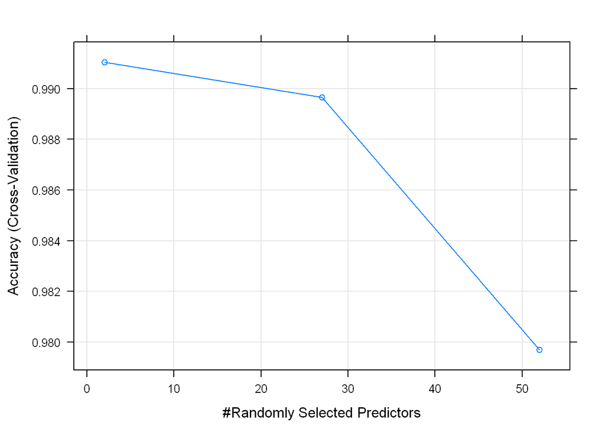

```r
        plot(Fit_rf)
```

**RANDOM FOREST** seems to do better, yeilds more accuracy, hence it was chosen as the final model.

## Checking OOB error

```r
        Fit_rf$finalModel
```

```
##
## Call:
##  randomForest(x = x, y = y, mtry = param$mtry)
##                Type of random forest: classification
##                      Number of trees: 500
## No. of variables tried at each split: 2
##
##         OOB estimate of  error rate: 0.63%
## Confusion matrix:
##      A    B    C    D    E  class.error
## A 3904    2    0    0    0 0.0005120328
## B   14 2638    6    0    0 0.0075244545
## C    0   14 2378    4    0 0.0075125209
## D    0    0   39 2211    2 0.0182060391
## E    0    0    0    6 2519 0.0023762376
```

The final random forest model yields **0.63%** out-og-bag estimated error rate.

## Applying model on the validation set

The random forest model was used to predict the classe on the validation set and resulted in the following confussion matrix:

```r
        predict_rf <- predict(Fit_rf, ftrn_v)
        confusionMatrix(ftrn_v$classe, predict_rf)
```

```
## Confusion Matrix and Statistics
##
##           Reference
## Prediction    A    B    C    D    E
##          A 1674    0    0    0    0
##          B    5 1132    2    0    0
##          C    0   12 1013    1    0
##          D    0    0   12  952    0
##          E    0    0    0    1 1081
##
## Overall Statistics
##
##                Accuracy : 0.9944
##                  95% CI : (0.9921, 0.9961)
##     No Information Rate : 0.2853
##     P-Value [Acc > NIR] : < 2.2e-16
##
##                   Kappa : 0.9929
##  Mcnemar's Test P-Value : NA
##
## Statistics by Class:
##
##                      Class: A Class: B Class: C Class: D Class: E
## Sensitivity            0.9970   0.9895   0.9864   0.9979   1.0000
## Specificity            1.0000   0.9985   0.9973   0.9976   0.9998
## Pos Pred Value         1.0000   0.9939   0.9873   0.9876   0.9991
## Neg Pred Value         0.9988   0.9975   0.9971   0.9996   1.0000
## Prevalence             0.2853   0.1944   0.1745   0.1621   0.1837
## Detection Rate         0.2845   0.1924   0.1721   0.1618   0.1837
## Detection Prevalence   0.2845   0.1935   0.1743   0.1638   0.1839
## Balanced Accuracy      0.9985   0.9940   0.9918   0.9977   0.9999
```

Accuracy of the validation set is **0.9944**.

The high accuracy on the validation set approves the model, and it can be use on the testing set for prediction.

# Applying final model on the testing set

```r
        predict(Fit_rf, tst)
```

```
##  [1] B A B A A E D B A A B C B A E E A B B B
## Levels: A B C D E
```